# TA Section: spatial data types, tmap and geocoding tips and warnings

QMSS Data Visualization - Spring 2021 - Week 06

Nico Rojas - nr2670@tc.columbia.edu

$~$

## 0 - Resources

*Warning*: For this TA section the references are particularly important, since the codes and examples of tmap are migrating to SF objects. The resources here gives you some places to look at to learn more from SF, although the general guidelines are here. Some commands in the slides were using sf objects like geom_sf(), but in this section there are some more references that can be helpful to do spatial data-wrangling among others.

$~$

- [Introduction to Spatial Data Types with R](https://cengel.github.io/rspatial/2_spDataTypes.nb.html) by Claudia Engel describes the different types of spatial data types in R.
- [Introduction to GIS with R](https://www.jessesadler.com/post/gis-with-r-intro/) by Jesse Sadler describes the SP and SF package.
- [A brief introduction to the tmap package](https://tlorusso.github.io/geodata_workshop/tmap_package) by Thomas Lo Russo & Max Grütter is a reference that was included in the slides from the course.
- (*Highly recommended*)[tmap: Thematic maps in R](https://www.jstatsoft.org/index.php/jss/article/view/v084i06/v84i06.pdf) by Martijn Tennekes, Journal of Statistical Software paper that lists all the features of tmap.
- [Creating maps with tmap](http://rstudio-pubs-static.s3.amazonaws.com/229482_b5b182f650434a36ace4eeef2d2bcd83.html#1) by Chris Bundson a short reference to tmap from Rstudio
- (*Highly recommended*) [Geocomputation with R](https://geocompr.robinlovelace.net/) by Robin Lovelace, Jakub Nowosad, Jannes Muenchow. A book on geographic data analysis, visualization and modeling. Is different from the other resources because it also provides detailed explanation about each of the different spatial operations (subsetting, spatial relationships, spatial joining, aggrergation, distance relationships.) Also, provides a comprehensive discussion of the `sf`type objects.
- [Making Maps with R](https://bookdown.org/nicohahn/making_maps_with_r5/docs/introduction.html) by Nico Hahn. Include tmap animations and an overview of different ways to draw maps in R.

This TASection draws intensively from [tmap: Thematic maps in R](https://www.jstatsoft.org/index.php/jss/article/view/v084i06/v84i06.pdf) by Martijn Tennekes

#### On your own

- Go to the website of [Geocomputation with R](https://geocompr.robinlovelace.net/) and read the vector attribute manipulation section.

$~$

## 1 - Summary: Spatial Data Types and sf objects

$~$

**Table 1 - types of data sets with geographic information outside R**

| Types of data sets | Description |
| --- | --- |
| Latitude and Longitude coordinates | Pair of coordinates. The most basic data. Can come in any file that supports a pair of numbers. |
| Shape files | Vector data: Include points, lines and polygon. The data necessairly comes in at least 3 files (.shp, .shx, .dbf extension and others). |
| Raster data | Raster data: the surface is represented as a grid of cells. |

**Table 2 - R spatial objects**

[output not shown]

#### *An example of an SF object*

The Tigris package allows to obtain sf polygons of census tracts and others from the US Census Bureau. Let’s open an sf object.

```r
# We import the data.
tracts2010 <- tracts("FLORIDA", year = 2010)
```

```r
# We check: it's SF
class(tracts2010)
```

```
## [1] "sf"         "data.frame"
```

*Since it’s an sf object, it’s a data frame with a geometric column. Find the column with spatial geometries.*

```r
glimpse(tracts2010)
```

```
## Rows: 4,245
## Columns: 15
## $ STATEFP10  <chr> "12", "12", "12", "12", "12", "12", "12", "12", "12", "1...
## $ COUNTYFP10 <chr> "009", "009", "009", "009", "009", "009", "009", "009", ...
## $ TRACTCE10  <chr> "068300", "068400", "068601", "068502", "068602", "98000...
## $ GEOID10    <chr> "12009068300", "12009068400", "12009068601", "1200906850...
## $ NAME10     <chr> "683", "684", "686.01", "685.02", "686.02", "9800", "713...
## $ NAMELSAD10 <chr> "Census Tract 683", "Census Tract 684", "Census Tract 68...
## $ MTFCC10    <chr> "G5020", "G5020", "G5020", "G5020", "G5020", "G5020", "G...
## $ FUNCSTAT10 <chr> "S", "S", "S", "S", "S", "S", "S", "S", "S", "S", "S", "...
## $ ALAND10    <dbl> 1886507, 1699567, 2981908, 1021413, 3243209, 65110387, 5...
## $ AWATER10   <dbl> 1893264, 6242872, 4187210, 549457, 1436745, 16731834, 45...
## $ INTPTLAT10 <chr> "+28.3410296", "+28.3579064", "+28.4044135", "+28.386084...
## $ INTPTLON10 <chr> "-080.6080301", "-080.6330330", "-080.6306937", "-080.59...
## $ geometry   <MULTIPOLYGON [°]> MULTIPOLYGON (((-80.60549 2..., MULTIPOLYGO...
## $ COUNTYFP   <chr> "009", "009", "009", "009", "009", "009", "009", "009", ...
## $ STATEFP    <chr> "12", "12", "12", "12", "12", "12", "12", "12", "12", "1...
```

How many census tracts?

```r
nrow(tracts2010)
```

```
## [1] 4245
```

#### On your own

- Use the command `data("World", "land", "rivers", package = "tmap")`
- Then, use `class` to get the class of each of these objects
- Find the `sf` objects, open the data frame and identify the column that has the geometry.
- Is any of the type of objects not included in table 1 and 2?
- Use $ to check the variables available inside sf objects.

$~$

## 2 - Spatial data-wrangling

$~$

Everything here is taken from [Geocomputation with R](https://geocompr.robinlovelace.net/) by Robin Lovelace, Jakub Nowosad, Jannes Muenchow. This book is highy recommned by some other of the references above.

Following this reference, we can decompose spatial data-wrangling (without considering raster data) into 3 types of operations.

- *Attribute operations*: operations that affect data is non-spatial information associated with geographic information.
- *Spatial operations*: operations that modify spatial objects in a multitude of ways based on their location and shape.
- *Geometric operations*: operations that in some way change the geometry of vector (sf)

Warning: only with vectorized data. I’m not including raster data. Check the reference.

```r
table3 <- read_xlsx("data/table.xlsx")
kable(table3, caption = "<b>Table 3 - Spatial Data Wrangling Operations<b>") %>%
  kable_styling("striped") %>%
  row_spec(0, color = "red", font_size = 18) %>%
  pack_rows("Attribute operations", 1, 4, label_row_css = "background-color: #666; color: #fff;") %>%
  pack_rows("Spatial operations", 5, 13, label_row_css = "background-color: #666; color: #fff;") %>%
  pack_rows("Geometric operations", 14, 18, label_row_css = "background-color: #666; color: #fff;")
```

**Table 3 - Spatial Data Wrangling Operations**

[output not shown]

You can also check more of the possibilites with sf objects using this command:

```r
methods(class="sf")
```

```
##  [1] $<-                   [                     [[<-
##  [4] aggregate             anti_join             arrange
##  [7] as.data.frame         cbind                 coerce
## [10] dbDataType            dbWriteTable          distinct
## [13] dplyr_reconstruct     filter                full_join
## [16] gather                group_by              group_split
## [19] identify              initialize            inner_join
## [22] left_join             merge                 mutate
## [25] nest                  plot                  print
## [28] rbind                 rename                right_join
## [31] rowwise               sample_frac           sample_n
## [34] select                semi_join             separate
## [37] separate_rows         show                  slice
## [40] slotsFromS3           spread                st_agr
## [43] st_agr<-              st_area               st_as_s2
```

[output cut: 19 more lines]

#### *Example of Spatial data Wrangling using st_ commands*

In this example, we will geolocate (the centroid) Dowtown Miami and then find all the census tracts that are within a certain distance of this location. The final result is a subset of all the census tracts from Florida.

Let’s first map all Florida’s census tract without any subsetting.

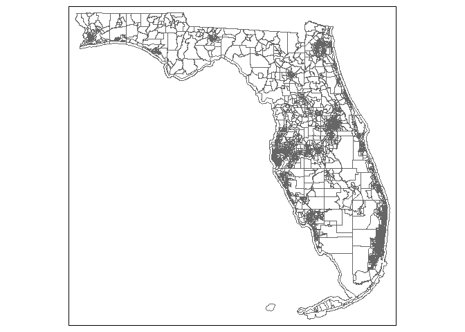

```r
# tracts2010 <- tracts("FLORIDA", year = 2010) We already did this above!
tm_shape(tracts2010) +
  tm_borders()
```

Now, let’s get the coordinates from Downtown miami, and find all the poluyones that are within a certain distance from that point.

```r
# With googleway:
# -------------- #
# ob <- google_geocode(address = "Downtown Miami, Miami, FL", simplify = TRUE) # We geocode downtown Miami
# miami_location <- (ob$results$geometry$location) # We substract the coordinates using googleway
# miami_location_point <- st_point(x = c(miami_location[1,2], miami_location[1,1])) # We convert the point into a geometric object

# Since you need a Google Key I will put the coordinates c(-80.19187, 25.77125) directly.

# First, we transform the coordinates into a geometric object
miami_location_point <- st_point(x =  c(-80.19187, 25.77125))

# We tranform the geometric object into a sfc object, sfc ojects are sf spatial ojects that have a projcetion ("CRS").
# We choose as a projection the same from the census tract.
projection_census <- st_crs(tracts2010)$input
miami_location_crs <- st_sfc(miami_location_point, crs = projection_census)

# We do the spatial merge. It will return an sgbp objetct that is a list that has all the intersections within 10000 distance units.
around_miami <- st_is_within_distance(tracts2010, miami_location_crs, dist = 10000)

# We transform the sgbp object into a matric with TRUE and FALSE for each of the census tract.
sel_logical <-  lengths(around_miami) > 0 # We look for the intersections

# We finally subset all the tracts to only the ones that are near Miami.
tracts2010_around_miami <- tracts2010[sel_logical, ] # We subset the intersections from the census tract.
```

Now, let’s map the final result. Voila!:

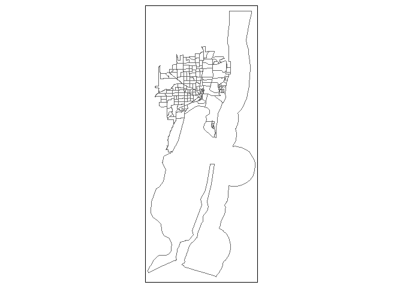

```r
# We map.
tm_shape(tracts2010_around_miami) +
  tm_borders()
```

$~$

## 3 - tmap: Thematic maps in R

$~$

### 3.1 - Why tmap?

- Flexible, layer-based, and easy to use approach to create maps
- Syntax based on “layered grammar of graphics” which is similar to that of ggplot2.
- Can manipulate sf, sp, and raster objects.
- Has a companion package “tmaptools” that contains convinient functions to read and process spatial data.

### 3.2 - tmap syntax

- Tmap syntax is based on element functions whose names have the prefix tm_ and that are stacked with the + operator, in the same way as in ggplot.
- The tmap syntax can be decomposed into 5 aspects:
1. Shape
2. Layers
3. Small multiples
4. Map Attributes
5. Layout

#### 3.2.1 - Shape

- The most fundamental element function is tm_shape. But you can’t draw a plot by using only tm_shape.
- One of the important arguments of the tm_shape function is the projection.

Example:

```r
# Here we are opneing the World option with the 4326 projection.
tm_shape(World, projection=4326)

# Here we are opneing the World option with the +proj=robin projection.
tm_shape(World, projection="+proj=robin")


# Rmarkdown note for this chunk: I used the eval = F option to include a a code that is not run but it's shown. This can be used to store pieces of code you don't want to run into a chunk.
```

#### On your own

- Open the world data-set from tm map using `data("World", "land", "rivers", package = "tmap")`
- Try to run a chunk with only tm_shape

#### 3.2.2 - Layers

- tm_shape should always be followed by one or more layers:
  - tm_polygons
  - tm_symbols
  - tm_lines
  - tm_raster
  - tm_text
  - tm_fill
  - tm_borders
  - tm_bubbles
  - tm_squares
  - tm_dots
  - tm_rgb
  - tm_markers
- Each of these layers have some aesthetics (color, size, shape, text labels etc…) that can be found using help, or online documentation.

#### Examples:

```r
# We will use the World, land rivers from the tmap data-set.
data("World", "land", "rivers", "metro",  package = "tmap")
```

#### Only fill

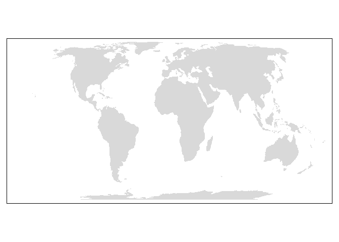

```r
tm_shape(World) + tm_fill()
```

#### Only borders

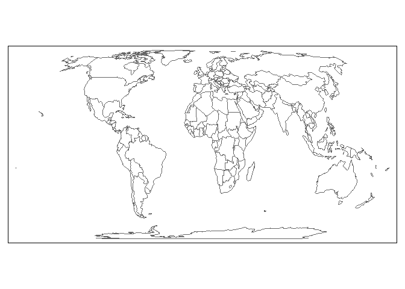

```r
tm_shape(World) + tm_borders()
```

#### Only polygons

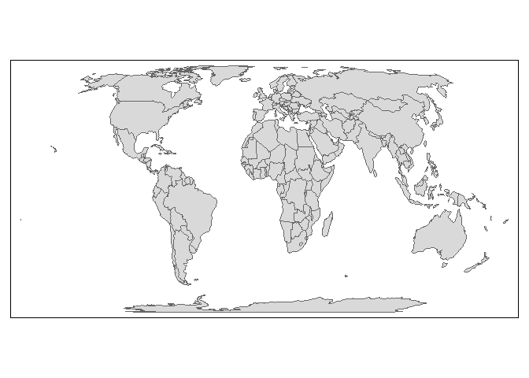

```r
tm_shape(World) + tm_polygons()
```

#### Only polygons: changing color the aesthetic

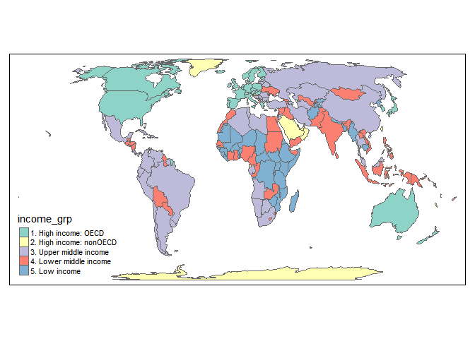

```r
tm_shape(World) + tm_polygons(col = "income_grp")
```

#### Only text

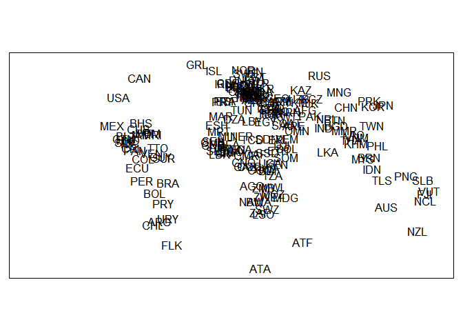

```r
tm_shape(World) + tm_text(text = "iso_a3")
```

#### Only text: changing the size aesthetic

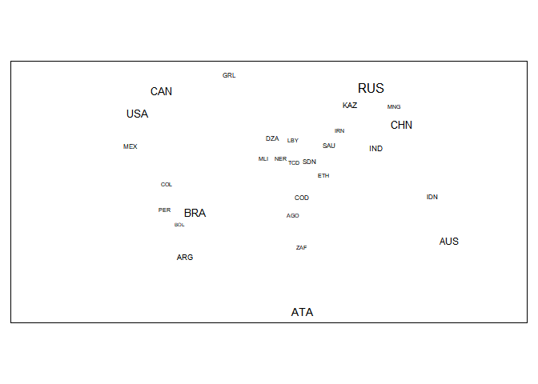

```r
tm_shape(World) + tm_text(text = "iso_a3", size = "AREA")
```

#### Only bubbles

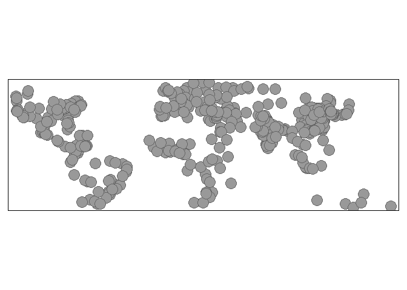

```r
# Note that this is a different shape files.
tm_shape(metro) +  tm_bubbles()
```

#### Only bubbles: changing the size aesthetic

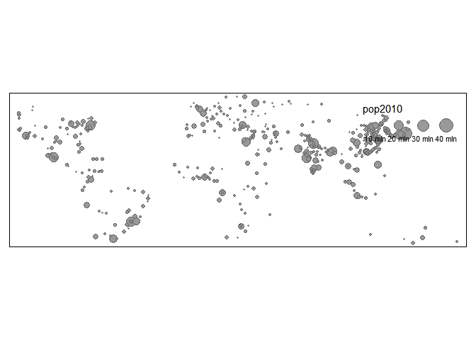

```r
# Note: What type of object is metro? Then, how can you open it: using $ or @
tm_shape(metro) +  tm_bubbles(size = "pop2010")
```

#### Everything together:

- Does the aesthetics look good? (ie. polygon colors)
- Why could this be a problem? (Remember week02)
- What do we do with this? (What tool did the professor mention to choose map colors?)

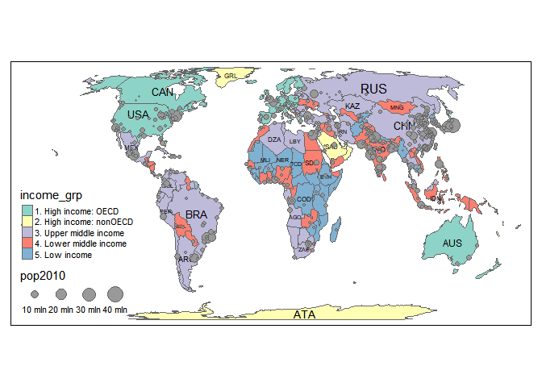

```r
# Note: You can combine many shape-files in the same plot.
tm_shape(World) + tm_polygons(col = "income_grp") +
tm_text(text = "iso_a3", size = "AREA") +
tm_shape(metro) +
tm_bubbles(size = "pop2010")
```

#### Everything together + changing the palette using the:

Question: Does this look better?

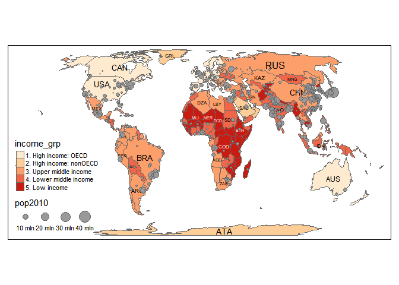

```r
tm_shape(World) +
tm_polygons(col = "income_grp", palette = "OrRd") +
tm_text(text = "iso_a3", size = "AREA") +
tm_shape(metro) +
tm_bubbles(size = "pop2010")
```

#### On your own

- Use the same and add each of the layers that were not presented here.
- For example: `tm_shape(World) + tm_fill()`

#### 2.2.3 - Small multiples

- Three alternatives:
1. a vector of constant values or data can be assigned to one of the aesthetics.
2. using tm_facets
3. using tmap_arrange
- tm_facets main arguments:
- “by =” The variable by which you will facet
- nrow and ncol: Defines the structure of the multiple plots.
- free.scales: define whether aesthetics should be free for each map.

#### 1) Using constant colors.

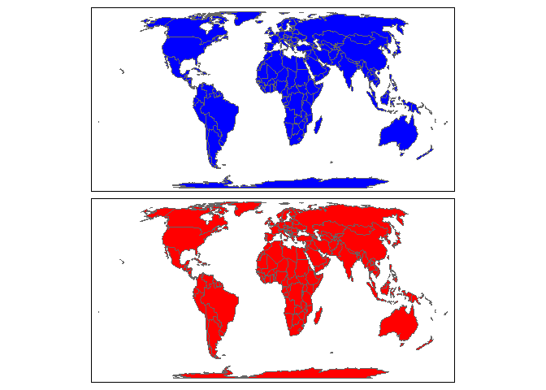

```r
tm_shape(World) + tm_polygons(col = c("blue", "red"))
```

#### 2) Using tm_facets.

```r
 tm_shape(World) + tm_polygons("red") + tm_facets(by = "continent", free.coords = TRUE, free.scales = F)
```

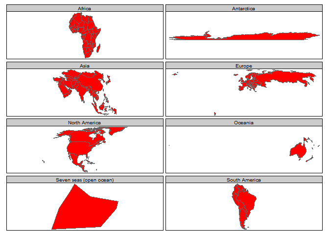

Since v2 of tmap the drop.units option *allows to not drop the areas that are not the main focus of the facet*. Then, it’s possible to maintain the polygons of the areas that are not emphasized by the facet. Note that this was highlighted as a problem during the lecture, and it can be solved with this new possibility of tm_facets.

```r
 tm_shape(World) + tm_polygons("red") + tm_facets(by = "continent", free.coords = FALSE, free.scales = F, drop.units = F)
```

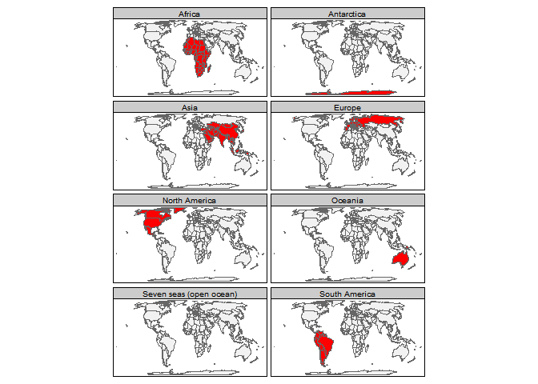

#### 3) Using tmap_arrange.

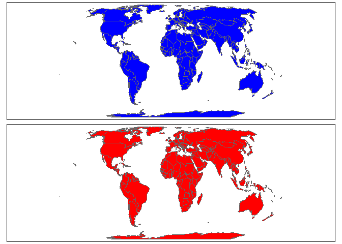

```r
map1 <- tm_shape(World) + tm_polygons(col = c("blue"))
map2 <- tm_shape(World) + tm_polygons(col = c("red"))
tmap_arrange(map1, map2)
```

#### 2.2.4 - Map attributes

Possible map attributes are:

- tm_grid
- tm_credits
- tm_scale_bar
- tm_compass
- tm_logo
- tm_xlab and tm_ylab

For this part we will use a Bavarian spatial data file. From Nico Hahn (2020) book.

```r
# Load data using the sf package
bavaria <- st_read("data/bavaria.shp")
# Fix colnames
colnames(bavaria) <- c(
  "place", "type", "gdp_per_capita", "mean_age",
  "pop_density", "unemployment_rate",
  "employment_rate", "household_income",
  "students", "pop_development", "geometry"
)
```

#### Base plot

This is just a map with a polygon layer.

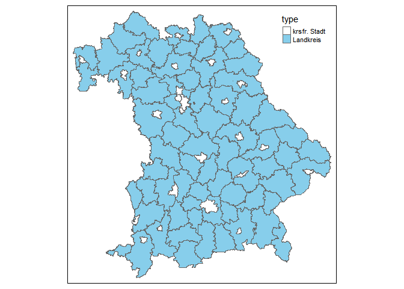

```r
# Rmarkdown note: When you use parenthesis in the beginning and the end of an object definition, you will store the object and plot at the same time
(base <- tm_shape(bavaria) +
  tm_polygons(col = "type", pal = c("white", "skyblue")))
```

#### Base plot + logo

[figure not shown]

```r
base + tm_logo("data/bavaria.png", height = 2)
```

#### Base plot + scale bar

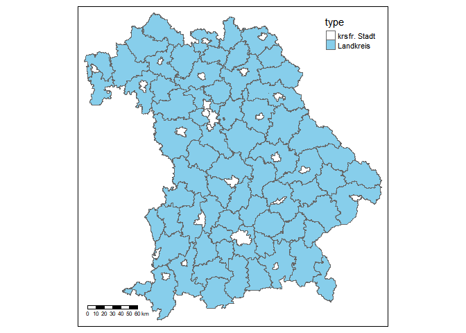

```r
base + tm_scale_bar(position = c("left", "bottom"), width = 0.15)
```

#### Base plot + compass

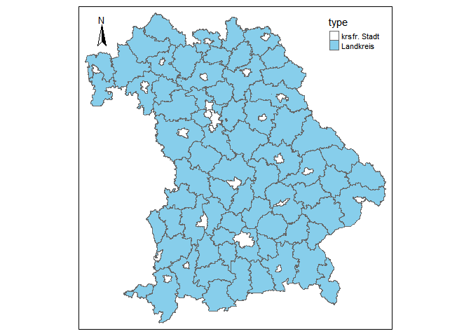

```r
base + tm_compass(position = c("left", "top"), size = 2)
```

#### Base plot + credits

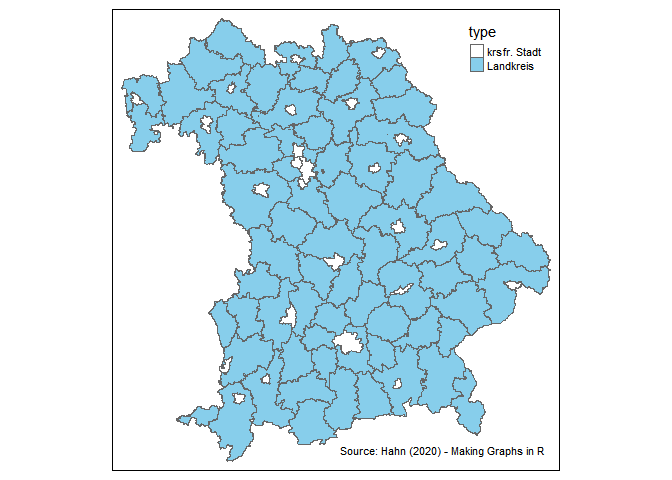

```r
base + tm_credits("Source: Hahn (2020) - Making Graphs in R", position=c("right", "bottom"))
```

#### Base plot + all the above map attributes

[figure not shown]

```r
tm_shape(bavaria) +
  tm_polygons(col = "type", pal = c("white", "skyblue")) +
  tm_logo("data/bavaria.png", height = 2) +
  tm_scale_bar(position = c("left", "bottom"), width = 0.15) +
  tm_compass(position = c("left", "top"), size = 2) +
  tm_credits("Source: Hahn (2020) - Making Graphs in R", position=c("right", "bottom"))
```

#### 2.2.5 - Layout

Possible layout attributes are:

- tm_layout (main argument: title)
- tm_legend (main argument: position)
- tm_format_X (main argument: inner.margins, outer.margins, asp, scale)
- tm_style (main argument: bg.color, aes.color, aes/palette)
- tm_view (main argument: alpha (transparency))

##### Layout:

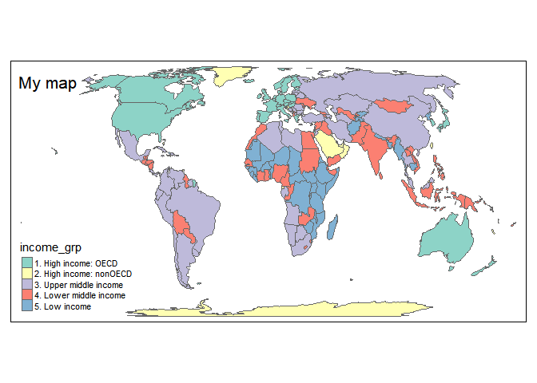

```r
tm_shape(World) + tm_polygons(col = "income_grp") + tm_layout(title = "My map")
```

##### Legend:

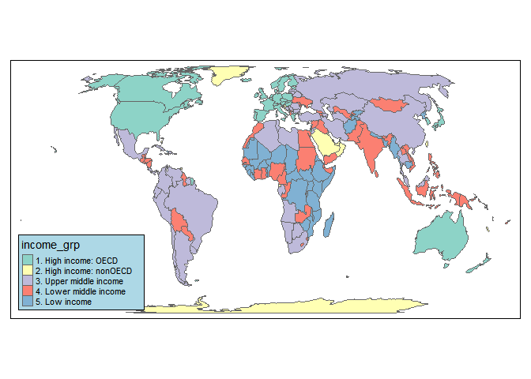

```r
tm_shape(World) +
  tm_polygons(col = "income_grp") +
  tm_legend(position = c("left", "bottom"),  frame = TRUE, bg.color="lightblue")
```

##### Style:

- Alternatives:

“classic”, white“,”gray“,”natural“,”cobalt“,”col_blind“,”albatross“,”beaver“,”bw“,”watercolor"

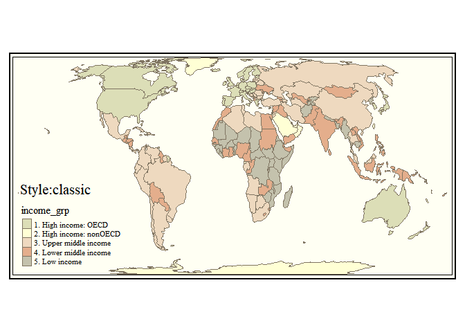

```r
tm_shape(World) +
  tm_polygons(col = "income_grp") +
  tm_style("classic") +
  tm_layout( title = paste0("Style:", "classic"), title.position = c("left", "bottom"))
```

Let’s show all the styles using small multiples:

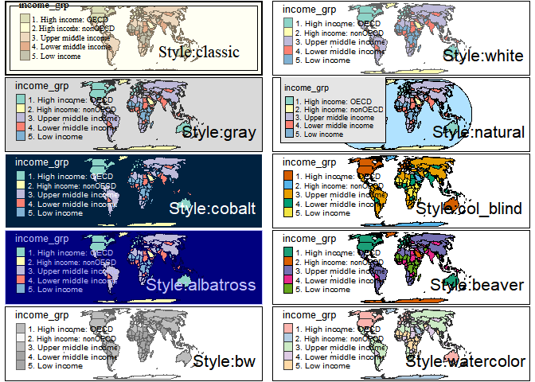

```r
styles = c("classic", "white", "gray", "natural", "cobalt", "col_blind", "albatross", "beaver", "bw", "watercolor")
myfunction <- function(style){
mymap <- tm_shape(World) +
  tm_polygons(col = "income_grp") +
  tm_style(paste0(style)) + tm_layout( title = paste0("Style:", style), title.position = c("right", "bottom"))
return(mymap)
}
maps <- lapply(styles, myfunction)
tmap_arrange(maps[[1]], maps[[2]], maps[[3]], maps[[4]], maps[[5]], maps[[6]], maps[[7]], maps[[8]], maps[[9]], maps[[10]], ncol = 2)
```

$~$

### 3.2 - Examples:

In this sub-section we will see some maps that integrate everything from above. Try to identify each of the tm_ elements that were described above.

Using Raster Data:

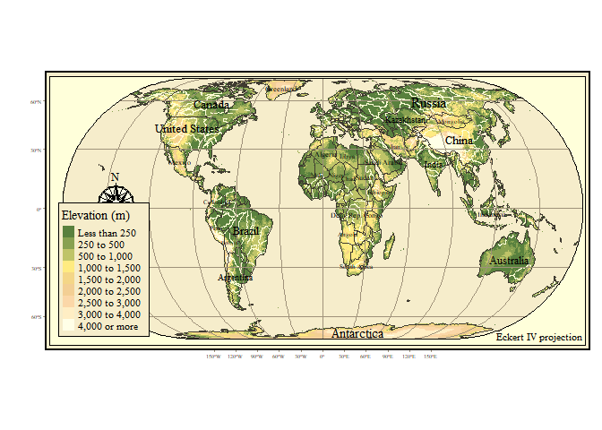

```r
# RMarkdown Note: This chunk was setup with "cache = T" because it takes sometime to load. Setting cache = T, makes R to use reuse the last-time you run the chunk if you haven't made any change to make things faster.
# Note: In this plot we combined raster data and shapefiles.
data("World", "land", "rivers", package = "tmap")

tm_shape(land, raster.warp = FALSE) +
  tm_raster("elevation", breaks = c(-Inf, 250, 500, 1000, 1500, 2000, 2500, 3000, 4000, Inf),
            palette = terrain.colors(9), title = "Elevation (m)") +
  tm_shape(rivers) +
  tm_lines("lightblue", lwd = "strokelwd", scale = 1.5, legend.lwd.show = FALSE) +
  tm_shape(World, is.master = TRUE) +
  tm_borders("grey20", lwd = .5) +
  tm_graticules(labels.size = 0.4, lwd = 0.25) +
  tm_text("name", size = "AREA") +
  tm_compass(position = c(0.08, 0.45), color.light = "grey90", size = 3) +
  tm_credits("Eckert IV projection", position = c("RIGHT", "BOTTOM")) +
  tm_style("classic",
           bg.color = "lightblue",
           space.color = "grey90",
           inner.margins = c(0.04, 0.04, 0.03, 0.02),
           earth.boundary = TRUE) +
  tm_legend(position = c("left", "bottom"),
            frame = TRUE,
            bg.color = "lightblue")
```

```r
# Data Wrangling
# Opens data.
crimes <-  rbind(read.csv("data/2015-10-city-of-london-street.csv"), read.csv("data/2015-10-metropolitan-street.csv"))
# create sf of known locations
crimes <- crimes[!is.na(crimes$Longitude) & !is.na(crimes$Latitude), ]
crimes <- st_as_sf(crimes, coords = c("Longitude", "Latitude"), crs = 4326)
# set map projection to British National Grid
crimes <- st_transform(crimes, crs = 27700)
# Downloads shape file of London using a function from  the rnaturalearth package
regions <- ne_download(scale = "large", type = "states", category = "cultural", returnclass = "sf")
# Data Wrangling
london <- regions[which(regions$region == "Greater London"),]
london <- st_transform(london, crs = 27700)
crimes_london <- crop_shape(crimes, london, polygon =  TRUE)
```

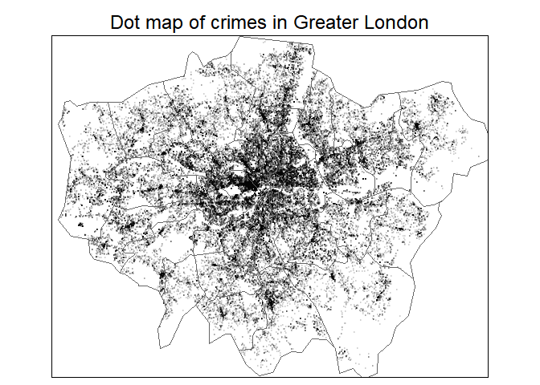

```r
# Draw map
tm_shape(crimes_london) +
tm_dots(alpha = 0.1) + # Makes the dots smaller by usingZ
tm_shape(london) +
tm_borders() + tm_layout(main.title = "Dot map of crimes in Greater London",  main.title.position = "center")
```

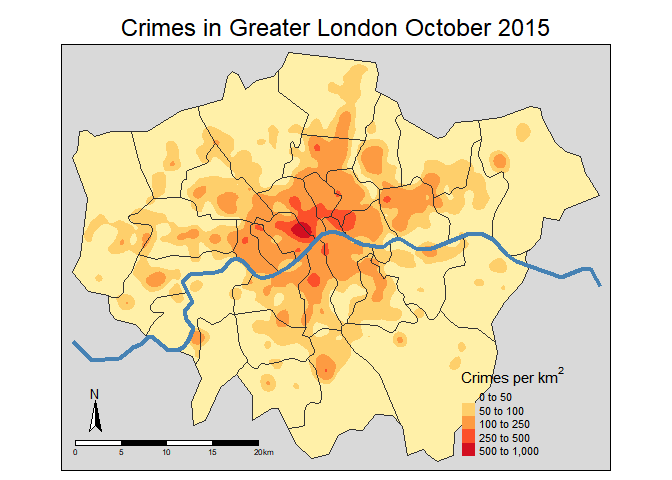

```r
# Data Wrangling
crime_densities <- smooth_map(crimes_london, bandwidth = 0.5, breaks = c(0, 50, 100, 250, 500, 1000), cover = london)

# download rivers, and get Thames shape
rivers <- ne_download(scale = "large", type = "rivers_lake_centerlines", category = "physical")
rivers <- st_as_sf(rivers) # Transform sp object into sf object to be able to use crop_shape
thames <- crop_shape(rivers, london)

# Draw map
tm_shape(crime_densities$polygons) +
  tm_fill(col = "level", palette = "YlOrRd", title = expression("Crimes per " * km^2)) +
  tm_shape(london) + tm_borders() +
  tm_shape(thames) + tm_lines(col = "steelblue", lwd = 4) + # Here we are adding the river on top of London
  tm_compass(position = c("left", "bottom")) +
  tm_scale_bar(position = c("left", "bottom")) +
  tm_style("gray", main.title = "Crimes in Greater London October 2015",  main.title.position = "center")
```

#### On your own

- Identify the Shapefiles (and raster files), Layers, Layout and Map Attributes in each of the tmap syntax
- What made the title to be positioned outside the box in the second graph?